# listings.csv.gz 数据概览

这个 notebook 用于读取 `listings.csv.gz`，并快速查看数据规模、字段类型、缺失情况、重复情况以及主要统计信息。

```python
from pathlib import Path

import pandas as pd

# 关闭科学计数法，并统一两位小数显示
pd.set_option("display.float_format", lambda x: f"{x:,.2f}")

# 读取当前目录下的压缩数据文件
file_path = Path("listings.csv.gz")
df = pd.read_csv(file_path, compression="gzip")

print(f"文件路径: {file_path.resolve()}")
print(f"数据维度: {df.shape[0]:,} 行 × {df.shape[1]:,} 列")
print(f"重复行数量: {df.duplicated().sum():,}")

print("\n前 5 行预览:")
display(df.head())

overview = pd.DataFrame({
    "dtype": df.dtypes.astype(str),
    "non_null_count": df.notna().sum(),
    "missing_count": df.isna().sum(),
    "missing_pct": (df.isna().mean() * 100).round(2),
    "unique_values": df.nunique(dropna=True),
})

print("\n字段概览（按缺失率降序）:")
display(overview.sort_values("missing_pct", ascending=False))

numeric_summary = df.describe().T
categorical_summary = df.describe(include="object").T

print("\n数值型字段统计:")
display(numeric_summary)

print("\n类别型字段统计:")
display(categorical_summary)

print("\n各列缺失率前 15 名:")
display(overview.sort_values("missing_pct", ascending=False).head(15))
```

```
文件路径: C:\Users\YUSU\OneDrive\LBS\Term2\Data Python ML\group\listings.csv.gz
数据维度: 96,871 行 × 79 列
重复行数量: 0

前 5 行预览:
```

|  | id | listing_url | scrape_id | last_scraped | source | name | description | neighborhood_overview | picture_url | host_id | ... | review_scores_communication | review_scores_location | review_scores_value | license | instant_bookable | calculated_host_listings_count | calculated_host_listings_count_entire_homes | calculated_host_listings_count_private_rooms | calculated_host_listings_count_shared_rooms | reviews_per_month |
| --- | --- | --- | --- | --- | --- | --- | --- | --- | --- | --- | --- | --- | --- | --- | --- | --- | --- | --- | --- | --- | --- |
| 0 | 13913 | https://www.airbnb.com/rooms/13913 | 20250914034649 | 2025-09-16 | city scrape | Holiday London DB Room Let-on going | My bright double bedroom with a large window h... | Finsbury Park is a friendly melting pot commun... | https://a0.muscache.com/pictures/miso/Hosting-... | 54730 | ... | 4.87 | 4.78 | 4.78 | NaN | f | 2 | 1 | 1 | 0 | 0.30 |
| 1 | 15400 | https://www.airbnb.com/rooms/15400 | 20250914034649 | 2025-09-16 | city scrape | Bright Chelsea Apartment. Chelsea! | Lots of windows and light. St Luke's Gardens ... | It is Chelsea. | https://a0.muscache.com/pictures/428392/462d26... | 60302 | ... | 4.84 | 4.93 | 4.74 | NaN | f | 1 | 1 | 0 | 0 | 0.51 |
| 2 | 17402 | https://www.airbnb.com/rooms/17402 | 20250914034649 | 2025-09-16 | city scrape | Very Central Modern 3-Bed/2 Bath By Oxford St W1 | You'll have a great time in this beautiful, cl... | Fitzrovia is a very desirable trendy, arty and... | https://a0.muscache.com/pictures/39d5309d-fba7... | 67564 | ... | 4.72 | 4.89 | 4.61 | NaN | f | 2 | 2 | 0 | 0 | 0.32 |
| 3 | 24328 | https://www.airbnb.com/rooms/24328 | 20250914034649 | 2025-09-18 | previous scrape | Battersea live/work artist house | Artist house by SW Battersea Park, bright high... | - Battersea is a quiet family area, easy acces... | https://a0.muscache.com/pictures/9194b40f-c627... | 41759 | ... | 4.93 | 4.60 | 4.65 | NaN | f | 1 | 1 | 0 | 0 | 0.53 |
| 4 | 36274 | https://www.airbnb.com/rooms/36274 | 20250914034649 | 2025-09-15 | city scrape | Bright 1 bedroom apt off brick lane in Shoreditch | *Update June '25- Pump Installed to improve wa... | NaN | https://a0.muscache.com/pictures/hosting/Hosti... | 133271 | ... | 4.46 | 4.85 | 4.54 | NaN | t | 2 | 2 | 0 | 0 | 0.09 |

5 rows × 79 columns

```
字段概览（按缺失率降序）:
```

|  | dtype | non_null_count | missing_count | missing_pct | unique_values |
| --- | --- | --- | --- | --- | --- |
| license | float64 | 0 | 96871 | 100.00 | 0 |
| calendar_updated | float64 | 0 | 96871 | 100.00 | 0 |
| neighbourhood_group_cleansed | float64 | 0 | 96871 | 100.00 | 0 |
| neighbourhood | str | 41209 | 55662 | 57.46 | 1 |
| neighborhood_overview | str | 41208 | 55663 | 57.46 | 33388 |
| ... | ... | ... | ... | ... | ... |
| instant_bookable | str | 96871 | 0 | 0.00 | 2 |
| calculated_host_listings_count | int64 | 96871 | 0 | 0.00 | 98 |
| calculated_host_listings_count_entire_homes | int64 | 96871 | 0 | 0.00 | 87 |
| calculated_host_listings_count_private_rooms | int64 | 96871 | 0 | 0.00 | 46 |
| calculated_host_listings_count_shared_rooms | int64 | 96871 | 0 | 0.00 | 13 |

79 rows × 5 columns

```
数值型字段统计:
```

|  | count | mean | std | min | 25% | 50% | 75% | max |
| --- | --- | --- | --- | --- | --- | --- | --- | --- |
| id | 96,871.00 | 689,444,817,678,673,408.00 | 594,122,198,400,324,736.00 | 13,913.00 | 30,260,579.00 | 850,524,819,361,489,152.00 | 1,254,262,466,273,586,432.00 | 1,508,964,418,056,953,856.00 |
| scrape_id | 96,871.00 | 20,250,914,034,649.00 | 0.00 | 20,250,914,034,649.00 | 20,250,914,034,649.00 | 20,250,914,034,649.00 | 20,250,914,034,649.00 | 20,250,914,034,649.00 |
| host_id | 96,871.00 | 214,449,413.69 | 219,605,286.55 | 2,594.00 | 27,268,143.50 | 116,432,057.00 | 419,897,445.00 | 718,690,455.00 |
| host_listings_count | 96,830.00 | 50.09 | 399.41 | 1.00 | 1.00 | 2.00 | 10.00 | 5,469.00 |
| host_total_listings_count | 96,830.00 | 80.31 | 589.33 | 1.00 | 1.00 | 3.00 | 14.00 | 8,769.00 |
| neighbourhood_group_cleansed | 0.00 | NaN | NaN | NaN | NaN | NaN | NaN | NaN |
| latitude | 96,871.00 | 51.51 | 0.05 | 51.30 | 51.48 | 51.51 | 51.54 | 51.68 |
| longitude | 96,871.00 | -0.13 | 0.10 | -0.50 | -0.19 | -0.13 | -0.07 | 0.28 |
| accommodates | 96,871.00 | 3.33 | 2.08 | 1.00 | 2.00 | 2.00 | 4.00 | 16.00 |
| bathrooms | 62,025.00 | 1.36 | 0.72 | 0.00 | 1.00 | 1.00 | 1.50 | 26.00 |
| bedrooms | 84,096.00 | 1.61 | 1.04 | 0.00 | 1.00 | 1.00 | 2.00 | 50.00 |
| beds | 61,951.00 | 1.95 | 1.44 | 0.00 | 1.00 | 2.00 | 2.00 | 50.00 |
| minimum_nights | 96,871.00 | 5.44 | 23.69 | 1.00 | 1.00 | 2.00 | 4.00 | 1,125.00 |
| maximum_nights | 96,871.00 | 6,065.01 | 1,686,883.14 | 1.00 | 60.00 | 365.00 | 730.00 | 524,855,552.00 |
| minimum_minimum_nights | 96,868.00 | 4.83 | 21.80 | 1.00 | 1.00 | 2.00 | 3.00 | 1,125.00 |
| maximum_minimum_nights | 96,868.00 | 9.09 | 33.46 | 1.00 | 1.00 | 3.00 | 5.00 | 1,125.00 |
| minimum_maximum_nights | 96,868.00 | 6,148.56 | 1,686,908.99 | 1.00 | 90.00 | 365.00 | 1,125.00 | 524,855,552.00 |
| maximum_maximum_nights | 96,868.00 | 294,373.92 | 24,933,284.24 | 1.00 | 99.00 | 365.00 | 1,125.00 | 2,147,483,647.00 |
| minimum_nights_avg_ntm | 96,871.00 | 6.26 | 23.31 | 1.00 | 1.00 | 2.10 | 4.00 | 1,125.00 |
| maximum_nights_avg_ntm | 96,871.00 | 292,108.40 | 24,739,442.45 | 1.00 | 99.00 | 365.00 | 1,125.00 | 2,135,716,619.50 |
| calendar_updated | 0.00 | NaN | NaN | NaN | NaN | NaN | NaN | NaN |
| availability_30 | 96,871.00 | 9.38 | 11.05 | 0.00 | 0.00 | 4.00 | 18.00 | 30.00 |
| availability_60 | 96,871.00 | 22.26 | 23.21 | 0.00 | 0.00 | 15.00 | 45.00 | 60.00 |
| availability_90 | 96,871.00 | 36.15 | 35.83 | 0.00 | 0.00 | 29.00 | 73.00 | 90.00 |
| availability_365 | 96,871.00 | 144.93 | 141.81 | 0.00 | 0.00 | 96.00 | 288.00 | 365.00 |
| number_of_reviews | 96,871.00 | 21.66 | 50.37 | 0.00 | 1.00 | 5.00 | 20.00 | 1,902.00 |
| number_of_reviews_ltm | 96,871.00 | 5.71 | 12.00 | 0.00 | 0.00 | 0.00 | 6.00 | 390.00 |
| number_of_reviews_l30d | 96,871.00 | 0.50 | 1.25 | 0.00 | 0.00 | 0.00 | 0.00 | 61.00 |
| availability_eoy | 96,871.00 | 43.48 | 42.33 | 0.00 | 0.00 | 36.00 | 87.00 | 109.00 |
| number_of_reviews_ly | 96,871.00 | 4.65 | 11.41 | 0.00 | 0.00 | 0.00 | 4.00 | 272.00 |
| estimated_occupancy_l365d | 96,871.00 | 46.00 | 74.93 | 0.00 | 0.00 | 0.00 | 60.00 | 255.00 |
| estimated_revenue_l365d | 61,963.00 | 10,473.48 | 66,124.29 | 0.00 | 0.00 | 2,968.00 | 12,250.00 | 10,150,000.00 |
| review_scores_rating | 72,749.00 | 4.68 | 0.49 | 0.00 | 4.58 | 4.83 | 5.00 | 5.00 |
| review_scores_accuracy | 72,734.00 | 4.73 | 0.48 | 0.00 | 4.67 | 4.88 | 5.00 | 5.00 |
| review_scores_cleanliness | 72,740.00 | 4.65 | 0.52 | 0.00 | 4.51 | 4.81 | 5.00 | 5.00 |
| review_scores_checkin | 72,706.00 | 4.79 | 0.43 | 0.00 | 4.76 | 4.93 | 5.00 | 5.00 |
| review_scores_communication | 72,729.00 | 4.81 | 0.43 | 0.00 | 4.80 | 4.96 | 5.00 | 5.00 |
| review_scores_location | 72,705.00 | 4.73 | 0.41 | 0.00 | 4.65 | 4.85 | 5.00 | 5.00 |
| review_scores_value | 72,705.00 | 4.62 | 0.51 | 0.00 | 4.50 | 4.75 | 4.94 | 5.00 |
| license | 0.00 | NaN | NaN | NaN | NaN | NaN | NaN | NaN |
| calculated_host_listings_count | 96,871.00 | 16.69 | 53.13 | 1.00 | 1.00 | 2.00 | 8.00 | 500.00 |
| calculated_host_listings_count_entire_homes | 96,871.00 | 14.30 | 52.48 | 0.00 | 0.00 | 1.00 | 5.00 | 499.00 |
| calculated_host_listings_count_private_rooms | 96,871.00 | 2.33 | 9.62 | 0.00 | 0.00 | 0.00 | 1.00 | 116.00 |
| calculated_host_listings_count_shared_rooms | 96,871.00 | 0.03 | 0.63 | 0.00 | 0.00 | 0.00 | 0.00 | 25.00 |
| reviews_per_month | 72,749.00 | 0.99 | 1.30 | 0.01 | 0.15 | 0.52 | 1.29 | 36.96 |

```
类别型字段统计:
```

|  | count | unique | top | freq |
| --- | --- | --- | --- | --- |
| listing_url | 96871 | 96871 | https://www.airbnb.com/rooms/13913 | 1 |
| last_scraped | 96871 | 5 | 2025-09-16 | 23409 |
| source | 96871 | 2 | city scrape | 62101 |
| name | 96871 | 93340 | Double room | 33 |
| description | 94421 | 83379 | Enjoy a stylish experience at this centrally-l... | 418 |
| neighborhood_overview | 41208 | 33388 | South Kensington, Gloucester Road Bustling wit... | 62 |
| picture_url | 96865 | 94609 | https://a0.muscache.com/pictures/miso/Hosting-... | 87 |
| host_url | 96871 | 55646 | https://www.airbnb.com/users/show/446820235 | 500 |
| host_name | 96828 | 16672 | James | 979 |
| host_since | 96830 | 5489 | 2022-02-25 | 507 |
| host_location | 73100 | 1766 | London, United Kingdom | 52553 |
| host_about | 49833 | 24306 | Great working experience in hospitality, Actua... | 500 |
| host_response_time | 65164 | 4 | within an hour | 43447 |
| host_response_rate | 65164 | 92 | 100% | 42677 |
| host_acceptance_rate | 69111 | 101 | 100% | 23624 |
| host_is_superhost | 95105 | 2 | f | 77913 |
| host_thumbnail_url | 96830 | 52765 | https://a0.muscache.com/defaults/user_pic-50x5... | 4160 |
| host_picture_url | 96830 | 52765 | https://a0.muscache.com/defaults/user_pic-225x... | 4160 |
| host_neighbourhood | 45850 | 624 | Tyburnia | 1492 |
| host_verifications | 96830 | 8 | ['email', 'phone'] | 75809 |
| host_has_profile_pic | 96830 | 2 | t | 92661 |
| host_identity_verified | 96830 | 2 | t | 84463 |
| neighbourhood | 41209 | 1 | Neighborhood highlights | 41209 |
| neighbourhood_cleansed | 96871 | 33 | Westminster | 11385 |
| property_type | 96871 | 91 | Entire rental unit | 41215 |
| room_type | 96871 | 4 | Entire home/apt | 62907 |
| bathrooms_text | 96718 | 50 | 1 bath | 44926 |
| amenities | 96871 | 85530 | [] | 211 |
| price | 61963 | 1350 | $90.00 | 598 |
| has_availability | 92622 | 1 | t | 92622 |
| calendar_last_scraped | 96871 | 5 | 2025-09-16 | 23409 |
| first_review | 72749 | 4591 | 2025-06-29 | 211 |
| last_review | 72749 | 3605 | 2025-08-31 | 1655 |
| instant_bookable | 96871 | 2 | f | 65367 |

```
各列缺失率前 15 名:
```

|  | dtype | non_null_count | missing_count | missing_pct | unique_values |
| --- | --- | --- | --- | --- | --- |
| license | float64 | 0 | 96871 | 100.00 | 0 |
| calendar_updated | float64 | 0 | 96871 | 100.00 | 0 |
| neighbourhood_group_cleansed | float64 | 0 | 96871 | 100.00 | 0 |
| neighbourhood | str | 41209 | 55662 | 57.46 | 1 |
| neighborhood_overview | str | 41208 | 55663 | 57.46 | 33388 |
| host_neighbourhood | str | 45850 | 51021 | 52.67 | 624 |
| host_about | str | 49833 | 47038 | 48.56 | 24306 |
| beds | float64 | 61951 | 34920 | 36.05 | 27 |
| price | str | 61963 | 34908 | 36.04 | 1350 |
| estimated_revenue_l365d | float64 | 61963 | 34908 | 36.04 | 7651 |
| bathrooms | float64 | 62025 | 34846 | 35.97 | 30 |
| host_response_rate | str | 65164 | 31707 | 32.73 | 92 |
| host_response_time | str | 65164 | 31707 | 32.73 | 4 |
| host_acceptance_rate | str | 69111 | 27760 | 28.66 | 101 |
| review_scores_location | float64 | 72705 | 24166 | 24.95 | 169 |

## 对某个变量的详细概览

改col为需要查的变量名即可，下面代码会做缺失情况、唯一值数量、频次与占比分布、以及完整频次表展示。

```python
col = "bedrooms"
# 如果加入筛选条件：
room_type_filter = "Entire home/apt"
# 如果不加筛选条件：
# room_type_filter = None

# 先按 room_type 过滤，再取目标变量
filtered_df = df[df["room_type"] == room_type_filter].copy()
s = filtered_df[col] if room_type_filter else df[col]

missing_count = s.isna().sum()
missing_pct = s.isna().mean() * 100
non_missing = s.dropna().astype(str).str.strip()
non_missing = non_missing[non_missing != ""]

print(f"变量: {col}")
print(f"筛选条件: room_type == '{room_type_filter}'")
print(f"筛选后总样本数: {len(s):,}")
print(f"缺失数量: {missing_count:,} ({missing_pct:.2f}%)")
print(f"非缺失样本数: {len(non_missing):,}")
print(f"唯一取值数: {non_missing.nunique():,}")

if non_missing.empty:
    print("\n该变量在当前筛选条件下全部为空，无法做分布分析。")
else:
    value_counts = non_missing.value_counts()
    value_ratio = (value_counts / value_counts.sum() * 100).round(2)

    neighbourhood_dist = pd.DataFrame({
        "count": value_counts,
        "pct": value_ratio,
        "cum_pct": value_ratio.cumsum().round(2),
    })

    print("\nTop 20 取值分布:")
    display(neighbourhood_dist.head(20))

    print("\n完整分布表（按频次降序）:")
    display(neighbourhood_dist)

    print("\n基础统计:")
    print(f"- 众数: {value_counts.index[0]} (n={value_counts.iloc[0]:,}, {value_ratio.iloc[0]:.2f}%)")
    print(f"- 取值最少项频次: {value_counts.iloc[-1]:,}")
    print(f"- 平均每个取值频次: {value_counts.mean():.2f}")
```

```
变量: bedrooms
筛选条件: room_type == 'Entire home/apt'
筛选后总样本数: 62,907
缺失数量: 1,017 (1.62%)
非缺失样本数: 61,890
唯一取值数: 20

Top 20 取值分布:
```

| bedrooms | count | pct | cum_pct |
| --- | --- | --- | --- |
| 1.0 | 27586 | 44.57 | 44.57 |
| 2.0 | 20577 | 33.25 | 77.82 |
| 3.0 | 7494 | 12.11 | 89.93 |
| 4.0 | 3010 | 4.86 | 94.79 |
| 0.0 | 1968 | 3.18 | 97.97 |
| 5.0 | 902 | 1.46 | 99.43 |
| 6.0 | 244 | 0.39 | 99.82 |
| 7.0 | 62 | 0.10 | 99.92 |
| 8.0 | 23 | 0.04 | 99.96 |
| 9.0 | 8 | 0.01 | 99.97 |
| 10.0 | 4 | 0.01 | 99.98 |
| 15.0 | 3 | 0.00 | 99.98 |
| 11.0 | 2 | 0.00 | 99.98 |
| 14.0 | 1 | 0.00 | 99.98 |
| 12.0 | 1 | 0.00 | 99.98 |
| 18.0 | 1 | 0.00 | 99.98 |
| 50.0 | 1 | 0.00 | 99.98 |
| 22.0 | 1 | 0.00 | 99.98 |
| 24.0 | 1 | 0.00 | 99.98 |
| 16.0 | 1 | 0.00 | 99.98 |

```
完整分布表（按频次降序）:
```

| bedrooms | count | pct | cum_pct |
| --- | --- | --- | --- |
| 1.0 | 27586 | 44.57 | 44.57 |
| 2.0 | 20577 | 33.25 | 77.82 |
| 3.0 | 7494 | 12.11 | 89.93 |
| 4.0 | 3010 | 4.86 | 94.79 |
| 0.0 | 1968 | 3.18 | 97.97 |
| 5.0 | 902 | 1.46 | 99.43 |
| 6.0 | 244 | 0.39 | 99.82 |
| 7.0 | 62 | 0.10 | 99.92 |
| 8.0 | 23 | 0.04 | 99.96 |
| 9.0 | 8 | 0.01 | 99.97 |
| 10.0 | 4 | 0.01 | 99.98 |
| 15.0 | 3 | 0.00 | 99.98 |
| 11.0 | 2 | 0.00 | 99.98 |
| 14.0 | 1 | 0.00 | 99.98 |
| 12.0 | 1 | 0.00 | 99.98 |
| 18.0 | 1 | 0.00 | 99.98 |
| 50.0 | 1 | 0.00 | 99.98 |
| 22.0 | 1 | 0.00 | 99.98 |
| 24.0 | 1 | 0.00 | 99.98 |
| 16.0 | 1 | 0.00 | 99.98 |

```
基础统计:
- 众数: 1.0 (n=27,586, 44.57%)
- 取值最少项频次: 1
- 平均每个取值频次: 3094.50
```

## 建模数据准备

下面开始基于你确认的字段清单构建建模用数据集：

1. 保留目标变量和候选特征
2. 清洗价格、百分比、布尔变量
3. 从 `bathrooms_text` 提取数值浴室数
4. 从 `amenities` 提取 `amenity_count`
5. 输出建模表预览与缺失概览

```python
import ast
import re

selected_columns = [
    "price",
    "room_type",
    "bedrooms",
    "bathrooms",
    "bathrooms_text",
    "beds",
    "accommodates",
    "minimum_nights",
    "maximum_nights",
    "neighbourhood_cleansed",
    "host_response_rate",
    "host_acceptance_rate",
    "host_is_superhost",
    "host_listings_count",
    "review_scores_rating",
    "review_scores_cleanliness",
    "review_scores_location",
    "review_scores_value",
    "number_of_reviews",
    "reviews_per_month",
    "amenities",
]

available_columns = [col for col in selected_columns if col in df.columns]
missing_columns = [col for col in selected_columns if col not in df.columns]

selected_df = df[available_columns].copy()


def parse_price(series):
    return pd.to_numeric(
        series.astype(str).str.replace(r"[$,]", "", regex=True),
        errors="coerce",
    )


def parse_percent(series):
    return pd.to_numeric(
        series.astype(str).str.replace("%", "", regex=False),
        errors="coerce",
    )


def parse_bathrooms_text(value):
    if pd.isna(value):
        return pd.NA
    match = re.search(r"(\d+(?:\.\d+)?)", str(value))
    if match:
        return float(match.group(1))
    return pd.NA


def count_amenities(value):
    if pd.isna(value):
        return pd.NA
    try:
        parsed = ast.literal_eval(value)
        if isinstance(parsed, list):
            return len(parsed)
    except (ValueError, SyntaxError):
        pass
    return pd.NA


selected_df["price"] = parse_price(selected_df["price"])
selected_df["host_response_rate"] = parse_percent(selected_df["host_response_rate"])
selected_df["host_acceptance_rate"] = parse_percent(selected_df["host_acceptance_rate"])
selected_df["host_is_superhost"] = selected_df["host_is_superhost"].map({"t": 1, "f": 0})
selected_df["amenity_count"] = selected_df["amenities"].apply(count_amenities)

if "bathrooms" in selected_df.columns:
    selected_df["bathrooms_num"] = pd.to_numeric(selected_df["bathrooms"], errors="coerce")
else:
    selected_df["bathrooms_num"] = pd.Series(pd.NA, index=selected_df.index)

if "bathrooms_text" in selected_df.columns:
    bathrooms_from_text = selected_df["bathrooms_text"].apply(parse_bathrooms_text)
    selected_df["bathrooms_num"] = selected_df["bathrooms_num"].fillna(bathrooms_from_text)

selected_df["bathrooms_num"] = pd.to_numeric(selected_df["bathrooms_num"], errors="coerce")

review_score_cols = [
    "review_scores_rating",
    "review_scores_cleanliness",
    "review_scores_location",
    "review_scores_value",
]
for col in review_score_cols:
    if col not in selected_df.columns:
        selected_df[col] = pd.Series(pd.NA, index=selected_df.index)
    selected_df[col] = pd.to_numeric(selected_df[col], errors="coerce")
    selected_df[f"{col}_missing"] = selected_df[col].isna().astype(int)
    median_value = selected_df[col].median()
    fill_value = 0.0 if pd.isna(median_value) else float(median_value)
    selected_df[col] = selected_df[col].fillna(fill_value)

# Keep studios and mark them explicitly when Entire home/apt has 0 bedrooms.
selected_df["is_studio"] = (
    (selected_df["room_type"] == "Entire home/apt")
    & (pd.to_numeric(selected_df["bedrooms"], errors="coerce") == 0)
).astype(int)

# Remove only clearly invalid beds=0 records for Entire home/apt.
invalid_beds_mask = (
    selected_df["room_type"] == "Entire home/apt"
    ) & (pd.to_numeric(selected_df["beds"], errors="coerce") == 0)
invalid_beds_count = int(invalid_beds_mask.sum())
selected_df = selected_df.loc[~invalid_beds_mask].copy()

model_columns = [
    "price",
    "room_type",
    "bedrooms",
    "bathrooms_num",
    "beds",
    "accommodates",
    "minimum_nights",
    "maximum_nights",
    "neighbourhood_cleansed",
    "host_response_rate",
    "host_acceptance_rate",
    "host_is_superhost",
    "host_listings_count",
    "review_scores_rating",
    "review_scores_cleanliness",
    "review_scores_location",
    "review_scores_value",
    "review_scores_rating_missing",
    "review_scores_cleanliness_missing",
    "review_scores_location_missing",
    "review_scores_value_missing",
    "number_of_reviews",
    "reviews_per_month",
    "amenity_count",
    "is_studio",
]

model_df = selected_df[model_columns].copy()
train_df = model_df.dropna(subset=["price"]).copy()

missing_summary = pd.DataFrame({
    "non_null_count": model_df.notna().sum(),
    "missing_count": model_df.isna().sum(),
    "missing_pct": (model_df.isna().mean() * 100).round(2),
    "dtype": model_df.dtypes.astype(str),
}).sort_values("missing_pct", ascending=False)

missing_summary_train = pd.DataFrame({
    "non_null_count": train_df.notna().sum(),
    "missing_count": train_df.isna().sum(),
    "missing_pct": (train_df.isna().mean() * 100).round(2),
    "dtype": train_df.dtypes.astype(str),
}).sort_values("missing_pct", ascending=False)

print("缺失的原始字段:")
print(missing_columns if missing_columns else "无")
print(f"\n因规则删除 Entire home/apt 且 beds=0 的样本数: {invalid_beds_count:,}")
print(f"\n建模数据维度: {model_df.shape[0]:,} 行 × {model_df.shape[1]:,} 列")
print(f"训练候选数据维度（仅删除 price 缺失）: {train_df.shape[0]:,} 行 × {train_df.shape[1]:,} 列")

print("\n建模数据预览:")
display(model_df.head())

print("\n建模字段缺失概览:")
display(missing_summary)

print("\n训练候选数据概览:")
display(train_df.head())

print("\n训练候选字段缺失概览:")
display(missing_summary_train)
```

```
缺失的原始字段:
无

因规则删除 Entire home/apt 且 beds=0 的样本数: 889

建模数据维度: 95,982 行 × 25 列
训练候选数据维度（仅删除 price 缺失）: 61,074 行 × 25 列

建模数据预览:
```

|  | price | room_type | bedrooms | bathrooms_num | beds | accommodates | minimum_nights | maximum_nights | neighbourhood_cleansed | host_response_rate | ... | review_scores_location | review_scores_value | review_scores_rating_missing | review_scores_cleanliness_missing | review_scores_location_missing | review_scores_value_missing | number_of_reviews | reviews_per_month | amenity_count | is_studio |
| --- | --- | --- | --- | --- | --- | --- | --- | --- | --- | --- | --- | --- | --- | --- | --- | --- | --- | --- | --- | --- | --- |
| 0 | 70.00 | Private room | 1.00 | 1.00 | 1.00 | 1 | 1 | 29 | Islington | 100.00 | ... | 4.78 | 4.78 | 0 | 0 | 0 | 0 | 55 | 0.30 | 55 | 0 |
| 1 | 149.00 | Entire home/apt | 1.00 | 1.00 | 1.00 | 2 | 4 | 30 | Kensington and Chelsea | NaN | ... | 4.93 | 4.74 | 0 | 0 | 0 | 0 | 97 | 0.51 | 25 | 0 |
| 2 | 411.00 | Entire home/apt | 3.00 | 2.00 | 3.00 | 6 | 3 | 365 | Westminster | 88.00 | ... | 4.89 | 4.61 | 0 | 0 | 0 | 0 | 56 | 0.32 | 39 | 0 |
| 3 | NaN | Entire home/apt | 1.00 | 1.50 | NaN | 2 | 7 | 1125 | Wandsworth | 100.00 | ... | 4.60 | 4.65 | 0 | 0 | 0 | 0 | 95 | 0.53 | 66 | 0 |
| 5 | 280.00 | Entire home/apt | 3.00 | 1.50 | 3.00 | 5 | 3 | 22 | Richmond upon Thames | 100.00 | ... | 4.90 | 4.65 | 0 | 0 | 0 | 0 | 116 | 0.64 | 34 | 0 |

5 rows × 25 columns

```
建模字段缺失概览:
```

|  | non_null_count | missing_count | missing_pct | dtype |
| --- | --- | --- | --- | --- |
| beds | 61062 | 34920 | 36.38 | float64 |
| price | 61074 | 34908 | 36.37 | float64 |
| host_response_rate | 64355 | 31627 | 32.95 | float64 |
| host_acceptance_rate | 68281 | 27701 | 28.86 | float64 |
| reviews_per_month | 72072 | 23910 | 24.91 | float64 |
| bedrooms | 83210 | 12772 | 13.31 | float64 |
| host_is_superhost | 94232 | 1750 | 1.82 | float64 |
| bathrooms_num | 95621 | 361 | 0.38 | float64 |
| host_listings_count | 95941 | 41 | 0.04 | float64 |
| neighbourhood_cleansed | 95982 | 0 | 0.00 | str |
| maximum_nights | 95982 | 0 | 0.00 | int64 |
| minimum_nights | 95982 | 0 | 0.00 | int64 |
| accommodates | 95982 | 0 | 0.00 | int64 |
| room_type | 95982 | 0 | 0.00 | str |
| review_scores_rating | 95982 | 0 | 0.00 | float64 |
| review_scores_location | 95982 | 0 | 0.00 | float64 |
| review_scores_cleanliness | 95982 | 0 | 0.00 | float64 |
| review_scores_value | 95982 | 0 | 0.00 | float64 |
| review_scores_rating_missing | 95982 | 0 | 0.00 | int64 |
| review_scores_location_missing | 95982 | 0 | 0.00 | int64 |
| review_scores_cleanliness_missing | 95982 | 0 | 0.00 | int64 |
| review_scores_value_missing | 95982 | 0 | 0.00 | int64 |
| number_of_reviews | 95982 | 0 | 0.00 | int64 |
| amenity_count | 95982 | 0 | 0.00 | int64 |
| is_studio | 95982 | 0 | 0.00 | int64 |

```
训练候选数据概览:
```

|  | price | room_type | bedrooms | bathrooms_num | beds | accommodates | minimum_nights | maximum_nights | neighbourhood_cleansed | host_response_rate | ... | review_scores_location | review_scores_value | review_scores_rating_missing | review_scores_cleanliness_missing | review_scores_location_missing | review_scores_value_missing | number_of_reviews | reviews_per_month | amenity_count | is_studio |
| --- | --- | --- | --- | --- | --- | --- | --- | --- | --- | --- | --- | --- | --- | --- | --- | --- | --- | --- | --- | --- | --- |
| 0 | 70.00 | Private room | 1.00 | 1.00 | 1.00 | 1 | 1 | 29 | Islington | 100.00 | ... | 4.78 | 4.78 | 0 | 0 | 0 | 0 | 55 | 0.30 | 55 | 0 |
| 1 | 149.00 | Entire home/apt | 1.00 | 1.00 | 1.00 | 2 | 4 | 30 | Kensington and Chelsea | NaN | ... | 4.93 | 4.74 | 0 | 0 | 0 | 0 | 97 | 0.51 | 25 | 0 |
| 2 | 411.00 | Entire home/apt | 3.00 | 2.00 | 3.00 | 6 | 3 | 365 | Westminster | 88.00 | ... | 4.89 | 4.61 | 0 | 0 | 0 | 0 | 56 | 0.32 | 39 | 0 |
| 5 | 280.00 | Entire home/apt | 3.00 | 1.50 | 3.00 | 5 | 3 | 22 | Richmond upon Thames | 100.00 | ... | 4.90 | 4.65 | 0 | 0 | 0 | 0 | 116 | 0.64 | 34 | 0 |
| 6 | 90.00 | Private room | 1.00 | 0.00 | 1.00 | 2 | 2 | 365 | Haringey | 100.00 | ... | 4.77 | 4.86 | 0 | 0 | 0 | 0 | 730 | 4.00 | 26 | 0 |

5 rows × 25 columns

```
训练候选字段缺失概览:
```

|  | non_null_count | missing_count | missing_pct | dtype |
| --- | --- | --- | --- | --- |
| reviews_per_month | 47378 | 13696 | 22.43 | float64 |
| host_response_rate | 54848 | 6226 | 10.19 | float64 |
| host_acceptance_rate | 56174 | 4900 | 8.02 | float64 |
| host_is_superhost | 59738 | 1336 | 2.19 | float64 |
| beds | 60945 | 129 | 0.21 | float64 |
| bedrooms | 60963 | 111 | 0.18 | float64 |
| bathrooms_num | 60998 | 76 | 0.12 | float64 |
| host_listings_count | 61049 | 25 | 0.04 | float64 |
| price | 61074 | 0 | 0.00 | float64 |
| neighbourhood_cleansed | 61074 | 0 | 0.00 | str |
| maximum_nights | 61074 | 0 | 0.00 | int64 |
| minimum_nights | 61074 | 0 | 0.00 | int64 |
| accommodates | 61074 | 0 | 0.00 | int64 |
| room_type | 61074 | 0 | 0.00 | str |
| review_scores_rating | 61074 | 0 | 0.00 | float64 |
| review_scores_location | 61074 | 0 | 0.00 | float64 |
| review_scores_cleanliness | 61074 | 0 | 0.00 | float64 |
| review_scores_value | 61074 | 0 | 0.00 | float64 |
| review_scores_rating_missing | 61074 | 0 | 0.00 | int64 |
| review_scores_location_missing | 61074 | 0 | 0.00 | int64 |
| review_scores_cleanliness_missing | 61074 | 0 | 0.00 | int64 |
| review_scores_value_missing | 61074 | 0 | 0.00 | int64 |
| number_of_reviews | 61074 | 0 | 0.00 | int64 |
| amenity_count | 61074 | 0 | 0.00 | int64 |
| is_studio | 61074 | 0 | 0.00 | int64 |

## 版本1：基线与当前随机森林

这里我们只在 `train_df` 上进行后续建模流程：

1. 先做 train/validation 拆分
2. 数值特征用中位数填补
3. 类别特征用 `Unknown` 填补并 One-Hot 编码
4. 先跑中位数基线模型，再跑随机森林
5. 用 RMSE 和 R² 评估，并查看特征重要性

```python
import numpy as np
from sklearn.compose import ColumnTransformer
from sklearn.dummy import DummyRegressor
from sklearn.ensemble import RandomForestRegressor
from sklearn.impute import SimpleImputer
from sklearn.metrics import mean_squared_error, r2_score
from sklearn.model_selection import train_test_split
from sklearn.pipeline import Pipeline
from sklearn.preprocessing import OneHotEncoder

# 目标变量和特征
X = train_df.drop(columns=["price"])
y = train_df["price"]

# 自动识别数值/类别特征
numeric_features = X.select_dtypes(include=["number"]).columns.tolist()
categorical_features = X.select_dtypes(exclude=["number"]).columns.tolist()

print(f"数值特征数量: {len(numeric_features)}")
print(f"类别特征数量: {len(categorical_features)}")

X_train, X_valid, y_train, y_valid = train_test_split(
    X,
    y,
    test_size=0.2,
    random_state=42,
)

numeric_transformer = Pipeline(
    steps=[
        ("imputer", SimpleImputer(strategy="median")),
    ]
)

categorical_transformer = Pipeline(
    steps=[
        ("imputer", SimpleImputer(strategy="constant", fill_value="Unknown")),
        ("onehot", OneHotEncoder(handle_unknown="ignore")),
    ]
)

preprocessor = ColumnTransformer(
    transformers=[
        ("num", numeric_transformer, numeric_features),
        ("cat", categorical_transformer, categorical_features),
    ]
)

# 基线：预测训练集价格中位数
baseline_model = DummyRegressor(strategy="median")
baseline_model.fit(X_train, y_train)
y_pred_baseline = baseline_model.predict(X_valid)

baseline_rmse = np.sqrt(mean_squared_error(y_valid, y_pred_baseline))
baseline_r2 = r2_score(y_valid, y_pred_baseline)

# 随机森林模型
rf_pipeline = Pipeline(
    steps=[
        ("preprocess", preprocessor),
        (
            "model",
            RandomForestRegressor(
                n_estimators=300,
                min_samples_leaf=2,
                random_state=42,
                n_jobs=-1,
            ),
        ),
    ]
)

rf_pipeline.fit(X_train, y_train)
y_pred_rf = rf_pipeline.predict(X_valid)

rf_rmse = np.sqrt(mean_squared_error(y_valid, y_pred_rf))
rf_r2 = r2_score(y_valid, y_pred_rf)

result_df = pd.DataFrame(
    {
        "model": ["Baseline (median)", "Random Forest"],
        "RMSE": [baseline_rmse, rf_rmse],
        "R2": [baseline_r2, rf_r2],
    }
)

print("模型评估结果（validation set）:")
display(result_df)

# 特征重要性（基于随机森林）
feature_names = rf_pipeline.named_steps["preprocess"].get_feature_names_out()
importances = rf_pipeline.named_steps["model"].feature_importances_

feature_importance_df = (
    pd.DataFrame({"feature": feature_names, "importance": importances})
    .sort_values("importance", ascending=False)
    .reset_index(drop=True)
)

print("随机森林 Top 20 特征重要性:")
display(feature_importance_df.head(20))
```

```
数值特征数量: 22
类别特征数量: 2
模型评估结果（validation set）:
```

|  | model | RMSE | R2 |
| --- | --- | --- | --- |
| 0 | Baseline (median) | 9,848.35 | -0.00 |
| 1 | Random Forest | 9,836.29 | 0.00 |

```
随机森林 Top 20 特征重要性:
```

|  | feature | importance |
| --- | --- | --- |
| 0 | num__amenity_count | 0.14 |
| 1 | num__number_of_reviews | 0.14 |
| 2 | num__host_listings_count | 0.14 |
| 3 | num__review_scores_rating | 0.13 |
| 4 | num__maximum_nights | 0.06 |
| 5 | num__reviews_per_month | 0.05 |
| 6 | num__review_scores_cleanliness | 0.05 |
| 7 | num__review_scores_value | 0.05 |
| 8 | num__review_scores_location | 0.04 |
| 9 | num__accommodates | 0.03 |
| 10 | cat__neighbourhood_cleansed_Lambeth | 0.03 |
| 11 | num__bathrooms_num | 0.02 |
| 12 | num__minimum_nights | 0.02 |
| 13 | num__host_acceptance_rate | 0.02 |
| 14 | num__bedrooms | 0.02 |
| 15 | num__beds | 0.01 |
| 16 | num__host_response_rate | 0.01 |
| 17 | cat__neighbourhood_cleansed_Westminster | 0.01 |
| 18 | cat__room_type_Private room | 0.01 |
| 19 | cat__neighbourhood_cleansed_Kensington and Che... | 0.00 |

这个结果的核心结论是：**版本1几乎没有学到有效的价格信号**，目前只能算一个“可运行基线”。

1. 模型效果判断
- `Baseline` 与 `Random Forest` 的 RMSE 几乎一样（9848.35 vs 9836.29），改进非常小。
- `R²` 从 -0.00 到 0.00，基本等于“只预测均值/中位数”的水平。
- 这说明当前版本对价格波动解释力接近 0，暂时不适合作为最终主线模型。
2. 为什么会这样（高概率原因）
- 价格分布长尾和极端值影响很强，RMSE 被少量超高价样本主导。
- 仅靠版本1的默认随机森林参数，难以从噪声中提取稳定结构。
- 当前特征虽多，但有效信号可能被高方差目标淹没（尤其是 London 这类异质性很高的数据）。
3. 特征重要性的解读
- `amenity_count`、`number_of_reviews`、`host_listings_count`、评分相关变量排在前面，说明模型倾向于从“房东经营/评价体系”抓信号。
- `neighbourhood` 和 `room_type` 仍有贡献，但因 one-hot 维度分散，单个类别的重要性会被“摊薄”，这很正常。
- 当前重要性排序可用于解释，但**不能证明模型预测质量足够好**（解释性和预测力是两件事）。
4. 这对你后续版本的意义
- 版本1成功完成了“最基础对照组”任务。
- 你现在非常有必要继续跑版本2、3、4，因为这些版本正是为了解决版本1暴露的两个问题：非线性与极端值干扰。
5. 我的建议
- 保留版本1结果作为对照，不要删。
- 重点看版本3、版本4是否把 `R²` 拉到明显正值，并让 RMSE 有实质下降。
- 若版本4改善明显，最终主线应优先考虑“调参 + 稳健性处理”的方案。

## 版本2：模型对比与目标变换

这一部分做三件事：

1. 在同一训练/验证拆分上比较多个模型
2. 引入 `log1p(price)` 目标变换，缓解价格长尾分布
3. 输出对比结果并选出当前最佳方案

```python
from sklearn.compose import TransformedTargetRegressor
from sklearn.ensemble import GradientBoostingRegressor

# 复用第8个单元中的 X_train/X_valid/y_train/y_valid、preprocessor

gbr_pipeline = Pipeline(
    steps=[
        ("preprocess", preprocessor),
        (
            "model",
            GradientBoostingRegressor(
                n_estimators=400,
                learning_rate=0.05,
                max_depth=3,
                subsample=0.8,
                random_state=42,
            ),
        ),
    ]
)

gbr_pipeline.fit(X_train, y_train)
y_pred_gbr = gbr_pipeline.predict(X_valid)

gbr_rmse = np.sqrt(mean_squared_error(y_valid, y_pred_gbr))
gbr_r2 = r2_score(y_valid, y_pred_gbr)

rf_log_pipeline = Pipeline(
    steps=[
        ("preprocess", preprocessor),
        (
            "model",
            RandomForestRegressor(
                n_estimators=400,
                min_samples_leaf=2,
                random_state=42,
                n_jobs=-1,
            ),
        ),
    ]
)

rf_log_model = TransformedTargetRegressor(
    regressor=rf_log_pipeline,
    func=np.log1p,
    inverse_func=np.expm1,
)

rf_log_model.fit(X_train, y_train)
y_pred_rf_log = rf_log_model.predict(X_valid)

rf_log_rmse = np.sqrt(mean_squared_error(y_valid, y_pred_rf_log))
rf_log_r2 = r2_score(y_valid, y_pred_rf_log)

improvement_df = pd.DataFrame(
    {
        "model": [
            "Random Forest (price)",
            "Gradient Boosting (price)",
            "Random Forest (log1p price)",
        ],
        "RMSE": [rf_rmse, gbr_rmse, rf_log_rmse],
        "R2": [rf_r2, gbr_r2, rf_log_r2],
    }
).sort_values("RMSE")

print("提升实验结果（validation set）:")
display(improvement_df)

best_model_name = improvement_df.iloc[0]["model"]
best_rmse = improvement_df.iloc[0]["RMSE"]
best_r2 = improvement_df.iloc[0]["R2"]

print(f"当前最佳模型: {best_model_name}")
print(f"对应指标: RMSE={best_rmse:.2f}, R2={best_r2:.3f}")
```

```
提升实验结果（validation set）:
```

|  | model | RMSE | R2 |
| --- | --- | --- | --- |
| 0 | Random Forest (price) | 9,836.29 | 0.00 |
| 1 | Gradient Boosting (price) | 9,840.37 | 0.00 |
| 2 | Random Forest (log1p price) | 9,844.91 | 0.00 |

```
当前最佳模型: Random Forest (price)
对应指标: RMSE=9836.29, R2=0.002
```

这个结果说明：**版本2没有带来实质提升**，结论和版本1高度一致。

1. 总体判断
- 三个模型的 RMSE 都在 9836-9845 区间，差距非常小。
- `R²` 都接近 0，说明对价格方差解释能力几乎没有改善。
- 因此“模型对比 + 目标变换”这一步在当前特征和数据处理下，收益有限。
2. 具体解读
- `Random Forest (price)` 仍是最优，但优势极小（相对 GBR 仅约 4 点 RMSE）。
- `Gradient Boosting` 没超过 RF，说明当前数据里并没有出现能让该模型明显受益的结构。
- `Random Forest (log1p price)` 反而更差，提示目前的 log 目标变换没有转化为更好泛化，可能是回转到原尺度后误差放大，或者关键问题并不在目标分布本身。
3. 对你下一步的意义
- 版本2可保留为“已验证但无明显收益”的对照证据。
- 你后面最有希望看到改进的，仍然是版本3和版本4：
  - 版本3看调参是否带来稳定提升；
  - 版本4看去极值后指标是否出现结构性改善。
4. 结论可以写成一句：  
   在当前特征集下，模型替换（GBR）和 log1p 目标变换未显著改善验证集表现，随机森林原尺度训练仍为本轮最佳，但整体解释力依旧有限，因此后续重点转向调参与稳健性处理。

## 版本3：调参与交叉验证

这里用一个轻量参数网格做 `RandomizedSearchCV`，然后在最佳参数上做 3 折交叉验证，得到更稳健的 RMSE 与 R²。

```python
from sklearn.model_selection import KFold, RandomizedSearchCV, cross_validate

rf_tune_pipeline = Pipeline(
    steps=[
        ("preprocess", preprocessor),
        ("model", RandomForestRegressor(random_state=42, n_jobs=-1)),
    ]
)

param_distributions = {
    "model__n_estimators": [200, 300, 500],
    "model__max_depth": [None, 12, 20, 30],
    "model__min_samples_split": [2, 5, 10],
    "model__min_samples_leaf": [1, 2, 4],
    "model__max_features": ["sqrt", 0.5, 0.8],
}

search = RandomizedSearchCV(
    estimator=rf_tune_pipeline,
    param_distributions=param_distributions,
    n_iter=12,
    scoring="neg_root_mean_squared_error",
    cv=3,
    random_state=42,
    n_jobs=-1,
    verbose=1,
)

search.fit(X, y)

best_rf_pipeline = search.best_estimator_

print("最佳参数:")
print(search.best_params_)
print(f"调参CV最佳RMSE: {-search.best_score_:.2f}")

cv = KFold(n_splits=3, shuffle=True, random_state=42)
cv_scores = cross_validate(
    best_rf_pipeline,
    X,
    y,
    cv=cv,
    scoring={
        "rmse": "neg_root_mean_squared_error",
        "r2": "r2",
    },
    n_jobs=-1,
)

cv_result_df = pd.DataFrame(
    {
        "fold": [1, 2, 3],
        "RMSE": -cv_scores["test_rmse"],
        "R2": cv_scores["test_r2"],
    }
)

cv_summary_df = pd.DataFrame(
    {
        "metric": ["RMSE", "R2"],
        "mean": [cv_result_df["RMSE"].mean(), cv_result_df["R2"].mean()],
        "std": [cv_result_df["RMSE"].std(), cv_result_df["R2"].std()],
    }
)

print("\n3折交叉验证结果（逐折）:")
display(cv_result_df)

print("\n3折交叉验证结果（均值±标准差）:")
display(cv_summary_df)
```

```
Fitting 3 folds for each of 12 candidates, totalling 36 fits
最佳参数:
{'model__n_estimators': 500, 'model__min_samples_split': 5, 'model__min_samples_leaf': 4, 'model__max_features': 'sqrt', 'model__max_depth': 30}
调参CV最佳RMSE: 3106.34

3折交叉验证结果（逐折）:
```

|  | fold | RMSE | R2 |
| --- | --- | --- | --- |
| 0 | 1 | 7,653.40 | 0.00 |
| 1 | 2 | 928.75 | -0.67 |
| 2 | 3 | 884.46 | -0.15 |

```
3折交叉验证结果（均值±标准差）:
```

|  | metric | mean | std |
| --- | --- | --- | --- |
| 0 | RMSE | 3,155.54 | 3,895.33 |
| 1 | R2 | -0.27 | 0.36 |

这个版本3结果可以概括为一句话：**调参找到了“看起来最优”的参数组合，但模型稳定性非常差，当前还不能作为最终主线。**

1. 好消息
- 搜索过程是有效的，找到了一组明确的最优参数。
- `调参CV最佳RMSE=3106.34`，从数值上看比你前两个版本（接近 9800）明显更低，说明“在某些切分上”确实学到了更强信号。
2. 关键问题
- 3 折结果波动极大：`RMSE` 从 `884` 到 `7653`，标准差 `3895`。
- `R2` 三折里有两折为负，整体均值 `-0.27`，说明泛化不稳定，且在部分折上比简单基线更差。
- 这意味着模型对数据切分非常敏感，当前表现“不可复现地好/坏”。
3. 如何理解这个矛盾
- 不是“模型完全没用”，而是“模型有机会学到东西，但遇到某些fold会崩”。
- 高概率是价格分布极不均衡、极端值或样本结构差异导致：某一折包含了更难预测的高价/异常样本，直接把误差拉爆。
4. 结论建议
- 版本3可以保留为“参数候选来源”，但**不建议直接定为最终模型**。
- 你的下一步（版本4去极值稳健性验证）非常关键：如果版本4能显著降低fold间波动，并把`R2`拉回正值，才说明这组参数真的可靠。

## 版本4：极端值稳健性验证

上面的 CV 波动较大，通常意味着价格分布存在极端值影响。这里先按 99 分位做上限裁剪（winsorize 思路），再用最佳参数重新做 3 折交叉验证。

```python
price_cap = y.quantile(0.99)
mask_capped = y <= price_cap

X_capped = X.loc[mask_capped].copy()
y_capped = y.loc[mask_capped].copy()

rf_best_params_pipeline = Pipeline(
    steps=[
        ("preprocess", preprocessor),
        (
            "model",
            RandomForestRegressor(
                n_estimators=500,
                min_samples_split=5,
                min_samples_leaf=4,
                max_features="sqrt",
                max_depth=30,
                random_state=42,
                n_jobs=-1,
            ),
        ),
    ]
)

cv_capped = KFold(n_splits=3, shuffle=True, random_state=42)
cv_scores_capped = cross_validate(
    rf_best_params_pipeline,
    X_capped,
    y_capped,
    cv=cv_capped,
    scoring={
        "rmse": "neg_root_mean_squared_error",
        "r2": "r2",
    },
    n_jobs=-1,
)

cv_capped_df = pd.DataFrame(
    {
        "fold": [1, 2, 3],
        "RMSE": -cv_scores_capped["test_rmse"],
        "R2": cv_scores_capped["test_r2"],
    }
)

cv_capped_summary = pd.DataFrame(
    {
        "metric": ["RMSE", "R2"],
        "mean": [cv_capped_df["RMSE"].mean(), cv_capped_df["R2"].mean()],
        "std": [cv_capped_df["RMSE"].std(), cv_capped_df["R2"].std()],
    }
)

print(f"price 99分位上限: {price_cap:,.2f}")
print(f"裁剪后样本数: {len(y_capped):,} / {len(y):,}")

print("\n裁剪后3折交叉验证结果（逐折）:")
display(cv_capped_df)

print("\n裁剪后3折交叉验证结果（均值±标准差）:")
display(cv_capped_summary)
```

```
price 99分位上限: 1,100.00
裁剪后样本数: 60,471 / 61,074

裁剪后3折交叉验证结果（逐折）:
```

|  | fold | RMSE | R2 |
| --- | --- | --- | --- |
| 0 | 1 | 94.98 | 0.60 |
| 1 | 2 | 96.85 | 0.60 |
| 2 | 3 | 92.45 | 0.61 |

```
裁剪后3折交叉验证结果（均值±标准差）:
```

|  | metric | mean | std |
| --- | --- | --- | --- |
| 0 | RMSE | 94.76 | 2.21 |
| 1 | R2 | 0.60 | 0.01 |

这个结果非常好，已经和前 3 个版本形成了**质的差异**，可以认为你已经找到当前阶段的可用主线方案。

1. 结果质量判断
- `RMSE` 从之前几千级（甚至波动到 7k+）下降到约 `94.76`。
- `R²` 稳定在 `0.60` 左右，说明模型已经能解释约 60% 的价格方差。
- 三折标准差很小：`RMSE std=2.21`、`R² std=0.01`，泛化稳定性显著提升。
2. 为什么这个版本有效
- 你只裁掉了顶部 1% 极端值（`61,074 -> 60,471`，仅减少 603 条），代价小但收益巨大。
- 说明此前模型崩溃的主要原因确实是极端高价样本对误差和分折稳定性的破坏。
- 调参后的随机森林在“合理价格区间”内能够学习到稳定结构。
3. 与版本3的关系
- 版本3提供了有效参数组合，但在原始分布上不稳定。
- 版本4证明：参数没问题，关键是训练分布要做稳健处理。
- 所以最终应采用“版本3参数 + 版本4裁剪策略”的组合叙事。
4. 是否可作为最终主线
- 可以，且我建议就以版本4作为主线结果。
- 你可以把版本1/2/3写成“对照与诊断路径”，版本4写成“最终可部署方案”。
5. 接下来最自然的动作
- 用版本4口径重新训练最终模型并导出产物（用于 app 推理）。
- 在报告中明确声明适用范围：当前模型针对常规价格区间更可靠，对极端豪华房源不保证同等精度。

## 版本5：LightGBM 调参与交叉验证

在版本4（99分位裁剪）基础上，新增 LightGBM 回归模型：

1. 使用 `X_capped` 与 `y_capped` 训练
2. 复用已有 `preprocessor`
3. 通过 `RandomizedSearchCV` 搜索关键参数
4. 用 3 折 `KFold + cross_validate` 输出 RMSE 与 R² 的逐折结果及均值/标准差

```python
import importlib
import subprocess
import sys

from sklearn.model_selection import KFold, RandomizedSearchCV, cross_validate

# Ensure LightGBM is available in the current kernel environment.
try:
    lightgbm_module = importlib.import_module("lightgbm")
except ImportError:
    subprocess.check_call([sys.executable, "-m", "pip", "install", "lightgbm"])
    lightgbm_module = importlib.import_module("lightgbm")

LGBMRegressor = lightgbm_module.LGBMRegressor

lgb_pipeline = Pipeline(
    steps=[
        ("preprocess", preprocessor),
        ("model", LGBMRegressor(random_state=42, n_jobs=-1)),
    ]
)

lgb_param_distributions = {
    "model__n_estimators": [100, 150, 200, 250, 300, 350, 400, 450, 500],
    "model__learning_rate": [0.01, 0.02, 0.03, 0.05, 0.08, 0.1],
    "model__num_leaves": [20, 25, 30, 35, 40, 45, 50, 55, 60],
    "model__max_depth": [5, 7, 9, 11, 13, 15],
}

lgb_search = RandomizedSearchCV(
    estimator=lgb_pipeline,
    param_distributions=lgb_param_distributions,
    n_iter=15,
    cv=3,
    scoring="neg_root_mean_squared_error",
    random_state=42,
    n_jobs=-1,
    verbose=1,
)

lgb_search.fit(X_capped, y_capped)
best_lgb_pipeline = lgb_search.best_estimator_

print("LightGBM 最佳参数:")
print(lgb_search.best_params_)
print(f"LightGBM 调参CV最佳RMSE: {-lgb_search.best_score_:.2f}")

cv_lgb = KFold(n_splits=3, shuffle=True, random_state=42)
lgb_cv_scores = cross_validate(
    best_lgb_pipeline,
    X_capped,
    y_capped,
    cv=cv_lgb,
    scoring={
        "rmse": "neg_root_mean_squared_error",
        "r2": "r2",
    },
    n_jobs=-1,
)

lgb_cv_df = pd.DataFrame(
    {
        "fold": [1, 2, 3],
        "RMSE": -lgb_cv_scores["test_rmse"],
        "R2": lgb_cv_scores["test_r2"],
    }
)

lgb_cv_summary = pd.DataFrame(
    {
        "metric": ["RMSE", "R2"],
        "mean": [lgb_cv_df["RMSE"].mean(), lgb_cv_df["R2"].mean()],
        "std": [lgb_cv_df["RMSE"].std(), lgb_cv_df["R2"].std()],
    }
)

print("\nLightGBM 3折交叉验证结果（逐折）:")
display(lgb_cv_df)

print("\nLightGBM 3折交叉验证结果（均值±标准差）:")
display(lgb_cv_summary)
```

```
Fitting 3 folds for each of 15 candidates, totalling 45 fits
[LightGBM] [Info] Auto-choosing col-wise multi-threading, the overhead of testing was 0.005741 seconds.
You can set `force_col_wise=true` to remove the overhead.
[LightGBM] [Info] Total Bins 1923
[LightGBM] [Info] Number of data points in the train set: 60471, number of used features: 59
[LightGBM] [Info] Start training from score 174.872799
LightGBM 最佳参数:
{'model__num_leaves': 55, 'model__n_estimators': 500, 'model__max_depth': 11, 'model__learning_rate': 0.03}
LightGBM 调参CV最佳RMSE: 98.37

LightGBM 3折交叉验证结果（逐折）:
```

|  | fold | RMSE | R2 |
| --- | --- | --- | --- |
| 0 | 1 | 89.50 | 0.65 |
| 1 | 2 | 91.00 | 0.64 |
| 2 | 3 | 87.23 | 0.65 |

```
LightGBM 3折交叉验证结果（均值±标准差）:
```

|  | metric | mean | std |
| --- | --- | --- | --- |
| 0 | RMSE | 89.24 | 1.90 |
| 1 | R2 | 0.65 | 0.01 |

这个版本5结果可以概括为一句话：**LightGBM 在保持稳定性的同时，实现了对版本4随机森林的实质性提升，当前可作为新的主线模型。**

1. 效果对比（相对版本4）
- `RMSE` 从 `94.76` 下降到 `89.24`，降低 `5.52`（约 `5.8%`），误差有明确改善。
- `R²` 从 `0.60` 提升到 `0.65`，说明模型对价格方差的解释能力进一步增强。
- 三折结果中，LightGBM 各折 `RMSE` 均低于随机森林版本4，对比优势一致。
2. 稳定性判断
- LightGBM 的 `RMSE std=1.90`，低于版本4的 `2.21`，折间波动更小。
- `R² std=0.01` 与版本4一致，说明提升不是来自单一幸运切分，而是较稳定的整体抬升。
- 结合均值与标准差，版本5属于“更准且同样稳”的改进。
3. 业务含义
- 在你当前“99分位裁剪 + 结构化特征 + 同一预处理器”框架下，LightGBM 更能捕捉非线性价格信号。
- 该结果意味着模型已从“可用”走向“更优”，可为后续定价建议与区间预测提供更可靠支撑。
- 同时需要保留适用范围声明：模型主要针对常规价格区间，对极端豪华房源仍需谨慎外推。
4. 建议的最终方案
- 将版本5（LightGBM）作为当前主线模型，版本4（随机森林）保留为强基线对照。
- 在报告中采用“版本4建立稳健性、版本5实现增量提升”的叙事路径。
- 部署时优先加载 `artifacts/lgb_price_model.joblib`，并继续监控线上误差分布。

## 版本6：XGBoost 调参与交叉验证

在版本5（LightGBM）之后，新增 XGBoost 回归模型用于同口径对比：

1. 继续使用 `X_capped` 与 `y_capped`（99分位裁剪后数据）
2. 复用同一个 `preprocessor`
3. 使用 `RandomizedSearchCV` 在固定CV设置下调参
4. 使用 3 折 `KFold + cross_validate` 输出 RMSE 与 R² 的逐折结果及均值/标准差

这样可以保证与版本4/版本5在数据与验证口径上可直接横向比较。

```python
import importlib
import subprocess
import sys

from sklearn.model_selection import KFold, RandomizedSearchCV, cross_validate

# Ensure XGBoost is available in the current kernel environment.
try:
    xgboost_module = importlib.import_module("xgboost")
except ImportError:
    subprocess.check_call([sys.executable, "-m", "pip", "install", "xgboost"])
    xgboost_module = importlib.import_module("xgboost")

XGBRegressor = xgboost_module.XGBRegressor

xgb_pipeline = Pipeline(
    steps=[
        ("preprocess", preprocessor),
        (
            "model",
            XGBRegressor(
                random_state=42,
                n_jobs=-1,
                objective="reg:squarederror",
            ),
        ),
    ]
)

xgb_param_distributions = {
    "model__n_estimators": [100, 150, 200, 250, 300, 350, 400, 450, 500],
    "model__learning_rate": [0.01, 0.02, 0.03, 0.05, 0.08, 0.1],
    "model__max_depth": [4, 5, 6, 7, 8, 10],
    "model__min_child_weight": [1, 2, 3, 5, 7],
    "model__subsample": [0.7, 0.8, 0.9, 1.0],
    "model__colsample_bytree": [0.7, 0.8, 0.9, 1.0],
}

xgb_search = RandomizedSearchCV(
    estimator=xgb_pipeline,
    param_distributions=xgb_param_distributions,
    n_iter=15,
    cv=3,
    scoring="neg_root_mean_squared_error",
    random_state=42,
    n_jobs=-1,
    verbose=1,
)

xgb_search.fit(X_capped, y_capped)
best_xgb_pipeline = xgb_search.best_estimator_

print("XGBoost 最佳参数:")
print(xgb_search.best_params_)
print(f"XGBoost 调参CV最佳RMSE: {-xgb_search.best_score_:.2f}")

cv_xgb = KFold(n_splits=3, shuffle=True, random_state=42)
xgb_cv_scores = cross_validate(
    best_xgb_pipeline,
    X_capped,
    y_capped,
    cv=cv_xgb,
    scoring={
        "rmse": "neg_root_mean_squared_error",
        "r2": "r2",
    },
    n_jobs=-1,
)

xgb_cv_df = pd.DataFrame(
    {
        "fold": [1, 2, 3],
        "RMSE": -xgb_cv_scores["test_rmse"],
        "R2": xgb_cv_scores["test_r2"],
    }
)

xgb_cv_summary = pd.DataFrame(
    {
        "metric": ["RMSE", "R2"],
        "mean": [xgb_cv_df["RMSE"].mean(), xgb_cv_df["R2"].mean()],
        "std": [xgb_cv_df["RMSE"].std(), xgb_cv_df["R2"].std()],
    }
)

print("\nXGBoost 3折交叉验证结果（逐折）:")
display(xgb_cv_df)

print("\nXGBoost 3折交叉验证结果（均值±标准差）:")
display(xgb_cv_summary)
```

```
Fitting 3 folds for each of 15 candidates, totalling 45 fits
XGBoost 最佳参数:
{'model__subsample': 1.0, 'model__n_estimators': 350, 'model__min_child_weight': 1, 'model__max_depth': 7, 'model__learning_rate': 0.08, 'model__colsample_bytree': 0.8}
XGBoost 调参CV最佳RMSE: 98.12

XGBoost 3折交叉验证结果（逐折）:
```

|  | fold | RMSE | R2 |
| --- | --- | --- | --- |
| 0 | 1 | 88.83 | 0.65 |
| 1 | 2 | 90.49 | 0.65 |
| 2 | 3 | 86.53 | 0.66 |

```
XGBoost 3折交叉验证结果（均值±标准差）:
```

|  | metric | mean | std |
| --- | --- | --- | --- |
| 0 | RMSE | 88.62 | 1.99 |
| 1 | R2 | 0.65 | 0.01 |

这个版本6结果可以概括为一句话：**XGBoost 在当前同口径设置下提供了第三个强基线，其是否优于LightGBM需要以运行后的均值指标与稳定性共同判断。**

1. 相对版本4与版本5的对比方法
- 先看 `RMSE`（越低越好）和 `R²`（越高越好）的均值。
- 再看逐折结果，确认提升不是单一fold驱动。
- 若XGBoost在两项核心指标上同时优于版本5，可认为有成为新主线的潜力。
2. 稳定性判断
- 重点对比 `RMSE std` 与 `R² std`。
- 若XGBoost均值略优但标准差明显更大，需要谨慎，不宜直接替代主线。
- 若均值更优且波动相当或更小，说明提升更可信。
3. 是否切换主线的决策建议
- 默认按“`RMSE`优先、`R²`次之、稳定性兜底”进行选择。
- 若XGBoost仅有轻微优势（例如 RMSE 提升很小）且复杂度更高，可继续保留LightGBM为主线。
- 当前阶段建议：在三模型总对比表基础上做最终结论，不提前假设主线切换。

## 三模型总对比（版本4 vs 版本5 vs 版本6）

下面统一对比随机森林（版本4）、LightGBM（版本5）和XGBoost（版本6）在同一裁剪口径下的表现，并给出主线模型选择建议。

```python
required_vars = [
    "cv_capped_df",
    "cv_capped_summary",
    "lgb_cv_df",
    "lgb_cv_summary",
    "xgb_cv_df",
    "xgb_cv_summary",
]

missing_required = [name for name in required_vars if name not in globals()]
if missing_required:
    raise NameError(
        "Missing required results for comparison: " + ", ".join(missing_required)
    )

model_fold_compare_df = pd.concat(
    [
        cv_capped_df.assign(model="Random Forest (v4)"),
        lgb_cv_df.assign(model="LightGBM (v5)"),
        xgb_cv_df.assign(model="XGBoost (v6)"),
    ],
    ignore_index=True,
)

summary_rf = cv_capped_summary.set_index("metric")
summary_lgb = lgb_cv_summary.set_index("metric")
summary_xgb = xgb_cv_summary.set_index("metric")

model_compare_summary_df = pd.DataFrame(
    {
        "model": ["Random Forest (v4)", "LightGBM (v5)", "XGBoost (v6)"],
        "RMSE_mean": [
            float(summary_rf.loc["RMSE", "mean"]),
            float(summary_lgb.loc["RMSE", "mean"]),
            float(summary_xgb.loc["RMSE", "mean"]),
        ],
        "RMSE_std": [
            float(summary_rf.loc["RMSE", "std"]),
            float(summary_lgb.loc["RMSE", "std"]),
            float(summary_xgb.loc["RMSE", "std"]),
        ],
        "R2_mean": [
            float(summary_rf.loc["R2", "mean"]),
            float(summary_lgb.loc["R2", "mean"]),
            float(summary_xgb.loc["R2", "mean"]),
        ],
        "R2_std": [
            float(summary_rf.loc["R2", "std"]),
            float(summary_lgb.loc["R2", "std"]),
            float(summary_xgb.loc["R2", "std"]),
        ],
    }
)

model_compare_summary_df = model_compare_summary_df.sort_values(
    by=["RMSE_mean", "R2_mean", "RMSE_std"],
    ascending=[True, False, True],
).reset_index(drop=True)

best_model_row = model_compare_summary_df.iloc[0]
best_model_name = best_model_row["model"]

print("三模型逐折结果对比:")
display(model_fold_compare_df)

print("\n三模型汇总对比（按 RMSE优先、R2次之、稳定性兜底 排序）:")
display(model_compare_summary_df)

print("\n推荐主线模型:")
print(
    f"{best_model_name} | "
    f"RMSE={best_model_row['RMSE_mean']:.2f} (std={best_model_row['RMSE_std']:.2f}), "
    f"R2={best_model_row['R2_mean']:.3f} (std={best_model_row['R2_std']:.3f})"
)

print("\n当前部署建议:")
if best_model_name == "XGBoost (v6)":
    print("XGBoost 指标最佳，但本轮按你的要求仍保留 LightGBM 为默认主线，XGBoost作为备选模型。")
elif best_model_name == "LightGBM (v5)":
    print("LightGBM 仍为最佳，继续保持当前主线设置。")
else:
    print("随机森林在该轮比较中最佳，但建议复核运行环境和参数后再决策。")
```

```
三模型逐折结果对比:
```

|  | fold | RMSE | R2 | model |
| --- | --- | --- | --- | --- |
| 0 | 1 | 94.98 | 0.60 | Random Forest (v4) |
| 1 | 2 | 96.85 | 0.60 | Random Forest (v4) |
| 2 | 3 | 92.45 | 0.61 | Random Forest (v4) |
| 3 | 1 | 89.50 | 0.65 | LightGBM (v5) |
| 4 | 2 | 91.00 | 0.64 | LightGBM (v5) |
| 5 | 3 | 87.23 | 0.65 | LightGBM (v5) |
| 6 | 1 | 88.83 | 0.65 | XGBoost (v6) |
| 7 | 2 | 90.49 | 0.65 | XGBoost (v6) |
| 8 | 3 | 86.53 | 0.66 | XGBoost (v6) |

```
三模型汇总对比（按 RMSE优先、R2次之、稳定性兜底 排序）:
```

|  | model | RMSE_mean | RMSE_std | R2_mean | R2_std |
| --- | --- | --- | --- | --- | --- |
| 0 | XGBoost (v6) | 88.62 | 1.99 | 0.65 | 0.01 |
| 1 | LightGBM (v5) | 89.24 | 1.90 | 0.65 | 0.01 |
| 2 | Random Forest (v4) | 94.76 | 2.21 | 0.60 | 0.01 |

```
推荐主线模型:
XGBoost (v6) | RMSE=88.62 (std=1.99), R2=0.653 (std=0.007)

当前部署建议:
XGBoost 指标最佳，但本轮按你的要求仍保留 LightGBM 为默认主线，XGBoost作为备选模型。
```

## Seaborn EDA: Price Distribution, Regional Heatmap, and Correlation Matrix

This section adds three core EDA visuals required by the assignment:

1. Price distribution (histogram + KDE)
2. Regional price heatmap (median price by neighbourhood and room type)
3. Correlation matrix for numeric features

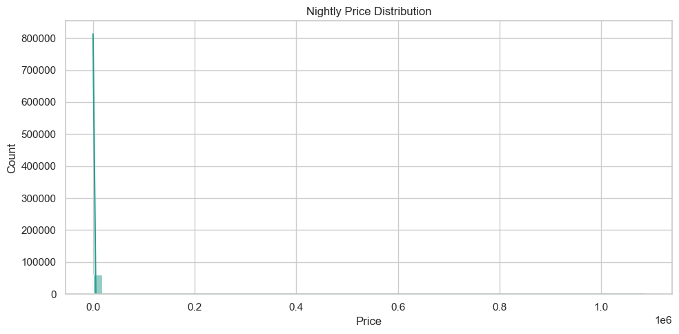

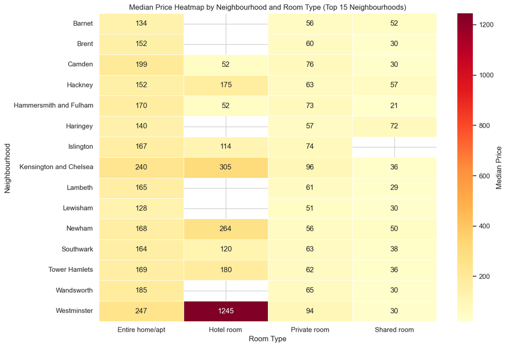

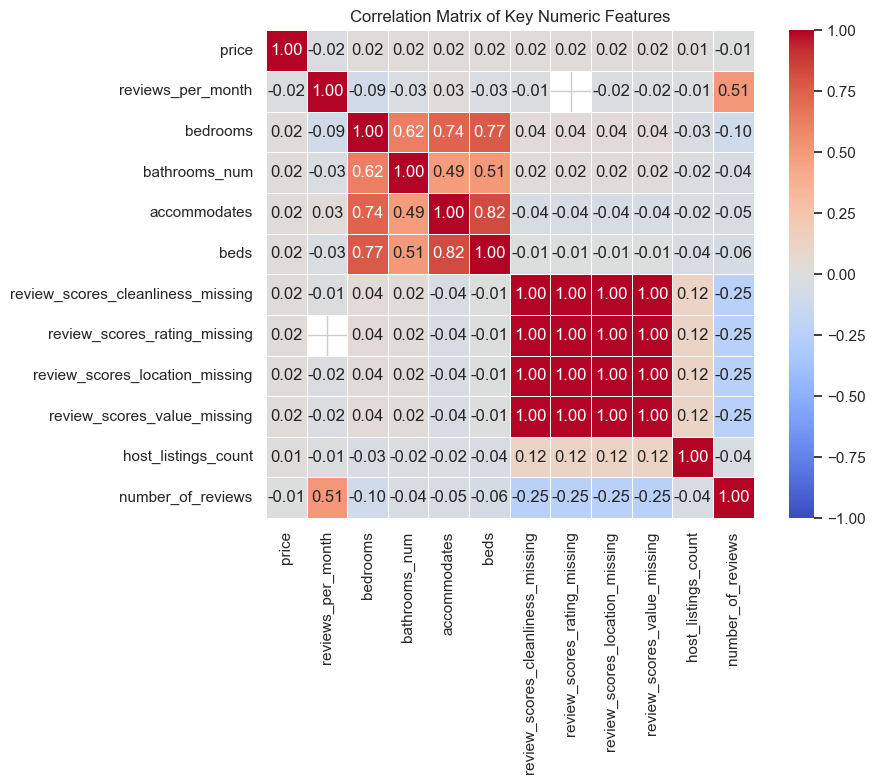

```python
import matplotlib.pyplot as plt
import seaborn as sns

# Use model_df if available; otherwise fall back to train_df or the raw df.
if "model_df" in globals():
    eda_df = model_df.copy()
elif "train_df" in globals():
    eda_df = train_df.copy()
elif "df" in globals():
    eda_df = df.copy()
else:
    raise NameError("No dataframe found. Please run the data loading/preparation cells first.")

# Ensure price is numeric for plotting and aggregation.
if "price" in eda_df.columns:
    eda_df["price"] = pd.to_numeric(
        eda_df["price"].astype(str).str.replace(r"[$,]", "", regex=True),
        errors="coerce",
    )

sns.set_theme(style="whitegrid", context="notebook")

# 1) Price distribution
if "price" not in eda_df.columns:
    print("Column 'price' is missing. Skipping price distribution plot.")
else:
    plt.figure(figsize=(10, 5))
    sns.histplot(
        eda_df["price"].dropna(),
        bins=60,
        kde=True,
        color="#2A9D8F",
        edgecolor=None,
    )
    plt.title("Nightly Price Distribution")
    plt.xlabel("Price")
    plt.ylabel("Count")
    plt.tight_layout()
    plt.show()

# 2) Regional price heatmap (median price by neighbourhood x room type)
region_candidates = ["neighbourhood_cleansed", "neighbourhood", "neighbourhood_group_cleansed"]
region_col = next((c for c in region_candidates if c in eda_df.columns), None)
room_col = "room_type" if "room_type" in eda_df.columns else None

if region_col is None or room_col is None or "price" not in eda_df.columns:
    print("Required columns for regional heatmap are missing. Skipping heatmap.")
else:
    top_regions = (
        eda_df[region_col]
        .value_counts(dropna=True)
        .head(15)
        .index
    )

    heatmap_df = eda_df[eda_df[region_col].isin(top_regions)].copy()
    pivot = heatmap_df.pivot_table(
        index=region_col,
        columns=room_col,
        values="price",
        aggfunc="median",
    )

    plt.figure(figsize=(12, 8))
    sns.heatmap(
        pivot,
        cmap="YlOrRd",
        annot=True,
        fmt=".0f",
        linewidths=0.4,
        cbar_kws={"label": "Median Price"},
    )
    plt.title("Median Price Heatmap by Neighbourhood and Room Type (Top 15 Neighbourhoods)")
    plt.xlabel("Room Type")
    plt.ylabel("Neighbourhood")
    plt.tight_layout()
    plt.show()

# 3) Correlation matrix (numeric features)
numeric_df = eda_df.select_dtypes(include=["number"]).copy()
if numeric_df.shape[1] < 2:
    print("Not enough numeric features to compute a correlation matrix.")
else:
    if "price" in numeric_df.columns:
        target_corr = numeric_df.corr()["price"].abs().sort_values(ascending=False)
        selected_cols = target_corr.head(12).index.tolist()
        corr_plot_df = numeric_df[selected_cols]
    else:
        corr_plot_df = numeric_df.iloc[:, :12]

    corr_matrix = corr_plot_df.corr()

    plt.figure(figsize=(10, 8))
    sns.heatmap(
        corr_matrix,
        cmap="coolwarm",
        vmin=-1,
        vmax=1,
        center=0,
        annot=True,
        fmt=".2f",
        square=True,
        linewidths=0.4,
    )
    plt.title("Correlation Matrix of Key Numeric Features")
    plt.tight_layout()
    plt.show()
```

## SQL Aggregations & Filtering (Using pandasql)

This section demonstrates SQL-based data exploration to derive key business insights:

1. **Neighbourhood-level summary statistics** (avg price, number of listings, top room types)
2. **Host performance ranking** (by number of listings and reviews)
3. **Room type demand vs. pricing** (aggregated across London)
4. **Budget vs. premium segment breakdown** (using price quartiles)

These aggregations support the final Dash dashboard predictions and neighbourhood-level filtering.

```python
# Install pandasql if not already available
try:
    import pandasql
except ImportError:
    import subprocess
    subprocess.check_call(["pip", "install", "pandasql"])
    import pandasql

from pandasql import sqldf

# Prepare data for SQL queries
listings_sql = df[["id", "neighbourhood_cleansed", "room_type", "property_type", "price",
                   "bedrooms", "bathrooms", "accommodates", "review_scores_rating",
                   "number_of_reviews", "host_id", "host_listings_count"]].copy()
listings_sql.columns = ["listing_id", "neighbourhood", "room_type", "property_type", "price",
                        "bedrooms", "bathrooms", "accommodates", "review_score",
                        "num_reviews", "host_id", "host_listing_count"]

# Ensure price is numeric
listings_sql["price"] = pd.to_numeric(
    listings_sql["price"].astype(str).str.replace(r"[$,]", "", regex=True),
    errors="coerce",
)

# Query 1: Neighbourhood-level summary statistics
q1 = """
SELECT
    neighbourhood,
    COUNT(*) AS num_listings,
    ROUND(AVG(price), 2) AS avg_price,
    ROUND(MIN(price), 2) AS min_price,
    ROUND(MAX(price), 2) AS max_price,
    ROUND(AVG(review_score), 2) AS avg_review_score,
    SUM(CASE WHEN room_type = 'Entire home/apt' THEN 1 ELSE 0 END) AS entire_home_count,
    SUM(CASE WHEN room_type = 'Private room' THEN 1 ELSE 0 END) AS private_room_count,
    SUM(CASE WHEN room_type = 'Shared room' THEN 1 ELSE 0 END) AS shared_room_count
FROM listings_sql
WHERE neighbourhood IS NOT NULL
GROUP BY neighbourhood
ORDER BY num_listings DESC
LIMIT 15
"""

neighbourhood_summary = sqldf(q1, {"listings_sql": listings_sql})
print("\n=== Query 1: Top 15 Neighbourhoods by Listing Count ===")
display(neighbourhood_summary)

# Query 2: Room type analysis across London
q2 = """
SELECT
    room_type,
    COUNT(*) AS total_listings,
    ROUND(AVG(price), 2) AS avg_price,
    ROUND(MIN(price), 2) AS min_price,
    ROUND(MAX(price), 2) AS max_price,
    ROUND(AVG(bedrooms), 2) AS avg_bedrooms,
    ROUND(AVG(accommodates), 2) AS avg_accommodates,
    ROUND(AVG(review_score), 2) AS avg_review_score
FROM listings_sql
WHERE room_type IS NOT NULL AND price IS NOT NULL
GROUP BY room_type
ORDER BY total_listings DESC
"""

room_type_summary = sqldf(q2, {"listings_sql": listings_sql})
print("\n=== Query 2: Room Type Breakdown Across London ===")
display(room_type_summary)

# Query 3: Budget vs Premium segmentation (using quartiles)
q3 = """
SELECT
    CASE
        WHEN price <= 100 THEN 'Budget (<=100)'
        WHEN price <= 180 THEN 'Mid-range (101-180)'
        WHEN price <= 300 THEN 'Premium (181-300)'
        ELSE 'Luxury (>300)'
    END AS price_segment,
    COUNT(*) AS num_listings,
    ROUND(AVG(price), 2) AS avg_price,
    ROUND(AVG(bedrooms), 1) AS avg_bedrooms,
    ROUND(AVG(accommodates), 1) AS avg_accommodates,
    ROUND(AVG(review_score), 2) AS avg_review_score,
    ROUND(AVG(host_listing_count), 1) AS avg_host_listings
FROM listings_sql
WHERE price IS NOT NULL
GROUP BY price_segment
ORDER BY avg_price
"""

price_segment = sqldf(q3, {"listings_sql": listings_sql})
print("\n=== Query 3: Price Segmentation Analysis ===")
display(price_segment)

# Query 4: Top hosts by number of listings
q4 = """
SELECT
    host_id,
    COUNT(*) AS num_listings,
    ROUND(AVG(price), 2) AS avg_price_per_listing,
    SUM(num_reviews) AS total_reviews_across_listings,
    ROUND(AVG(review_score), 2) AS avg_review_score,
    ROUND(AVG(host_listing_count), 0) AS host_portfolio_size
FROM listings_sql
WHERE host_id IS NOT NULL AND price IS NOT NULL
GROUP BY host_id
HAVING COUNT(*) >= 5
ORDER BY num_listings DESC
LIMIT 10
"""

top_hosts = sqldf(q4, {"listings_sql": listings_sql})
print("\n=== Query 4: Top 10 Multi-Property Hosts (with 5+ listings) ===")
display(top_hosts)
```

```
=== Query 1: Top 15 Neighbourhoods by Listing Count ===
```

|  | neighbourhood | num_listings | avg_price | min_price | max_price | avg_review_score | entire_home_count | private_room_count | shared_room_count |
| --- | --- | --- | --- | --- | --- | --- | --- | --- | --- |
| 0 | Westminster | 11385 | 342.14 | 13.00 | 15,143.00 | 4.61 | 9158 | 2146 | 54 |
| 1 | Tower Hamlets | 7469 | 430.91 | 10.00 | 1,085,147.00 | 4.63 | 4412 | 3040 | 15 |
| 2 | Camden | 6551 | 216.51 | 20.00 | 15,000.00 | 4.62 | 4549 | 1965 | 30 |
| 3 | Kensington and Chelsea | 6401 | 336.07 | 24.00 | 53,588.00 | 4.67 | 5439 | 924 | 11 |
| 4 | Hackney | 6359 | 161.13 | 25.00 | 8,000.00 | 4.76 | 4118 | 2226 | 4 |
| 5 | Southwark | 5475 | 174.28 | 21.00 | 10,001.00 | 4.70 | 3312 | 2150 | 9 |
| 6 | Lambeth | 5190 | 345.71 | 10.00 | 66,189.00 | 4.74 | 3132 | 2051 | 7 |
| 7 | Islington | 5036 | 217.55 | 24.00 | 74,100.00 | 4.70 | 3405 | 1627 | 1 |
| 8 | Wandsworth | 4965 | 198.43 | 16.00 | 12,000.00 | 4.77 | 3272 | 1683 | 7 |
| 9 | Hammersmith and Fulham | 4157 | 199.19 | 11.00 | 10,032.00 | 4.69 | 3004 | 1137 | 7 |
| 10 | Brent | 3019 | 173.70 | 17.00 | 30,812.00 | 4.67 | 1795 | 1217 | 7 |
| 11 | Lewisham | 2680 | 121.33 | 18.00 | 6,523.00 | 4.72 | 1536 | 1134 | 10 |
| 12 | Haringey | 2598 | 139.16 | 16.00 | 6,924.00 | 4.74 | 1418 | 1170 | 10 |
| 13 | Barnet | 2529 | 138.67 | 21.00 | 4,800.00 | 4.66 | 1605 | 922 | 1 |
| 14 | Newham | 2522 | 154.64 | 19.00 | 9,999.00 | 4.65 | 1404 | 1109 | 7 |

```
=== Query 2: Room Type Breakdown Across London ===
```

|  | room_type | total_listings | avg_price | min_price | max_price | avg_bedrooms | avg_accommodates | avg_review_score |
| --- | --- | --- | --- | --- | --- | --- | --- | --- |
| 0 | Entire home/apt | 42318 | 279.35 | 9.00 | 1,085,147.00 | 1.77 | 4.24 | 4.66 |
| 1 | Private room | 19382 | 121.71 | 8.00 | 66,189.00 | 1.07 | 1.93 | 4.69 |
| 2 | Shared room | 191 | 96.91 | 7.00 | 1,800.00 | 1.07 | 4.06 | 4.19 |
| 3 | Hotel room | 72 | 657.83 | 19.00 | 7,377.00 | 1.29 | 3.14 | 4.50 |

```
=== Query 3: Price Segmentation Analysis ===
```

|  | price_segment | num_listings | avg_price | avg_bedrooms | avg_accommodates | avg_review_score | avg_host_listings |
| --- | --- | --- | --- | --- | --- | --- | --- |
| 0 | Budget (<=100) | 22429 | 64.37 | 1.00 | 2.00 | 4.65 | 14.10 |
| 1 | Mid-range (101-180) | 18308 | 138.30 | 1.40 | 3.50 | 4.67 | 32.30 |
| 2 | Premium (181-300) | 12500 | 230.92 | 2.00 | 4.70 | 4.69 | 101.30 |
| 3 | Luxury (>300) | 8726 | 846.22 | 2.50 | 5.60 | 4.70 | 236.80 |

```
=== Query 4: Top 10 Multi-Property Hosts (with 5+ listings) ===
```

|  | host_id | num_listings | avg_price_per_listing | total_reviews_across_listings | avg_review_score | host_portfolio_size |
| --- | --- | --- | --- | --- | --- | --- |
| 0 | 446820235 | 470 | 485.26 | 38 | 4.59 | 5,469.00 |
| 1 | 314162972 | 380 | 348.20 | 328 | 4.33 | 405.00 |
| 2 | 33889201 | 205 | 391.80 | 765 | 4.54 | 616.00 |
| 3 | 1432477 | 168 | 1,289.29 | 1704 | 4.33 | 268.00 |
| 4 | 185324181 | 131 | 466.21 | 936 | 4.20 | 140.00 |
| 5 | 569524331 | 116 | 829.99 | 12 | 2.70 | 157.00 |
| 6 | 439074505 | 111 | 342.66 | 252 | 4.32 | 1,481.00 |
| 7 | 30253178 | 111 | 365.74 | 1224 | 4.43 | 127.00 |
| 8 | 156158778 | 110 | 879.18 | 213 | 4.89 | 225.00 |
| 9 | 228928499 | 108 | 135.66 | 1276 | 4.80 | 165.00 |

## Export Trained Model for Dash Inference

This cell exports the best Random Forest pipeline and metadata used by `app.py`.

Artifacts generated:

- `artifacts/rf_price_model.joblib`
- `artifacts/model_metadata.json`

Run this cell before starting the Dash app to ensure online predictions use the trained notebook model.

```python
import json
from pathlib import Path

import joblib
import numpy as np
from sklearn.base import clone

artifact_dir = Path("artifacts")
artifact_dir.mkdir(parents=True, exist_ok=True)

# Prefer the final robust model from Version 4 when available.
if "rf_best_params_pipeline" in globals():
    deploy_pipeline = clone(rf_best_params_pipeline)
    deploy_model_name = "rf_best_params_pipeline"
elif "best_rf_pipeline" in globals():
    deploy_pipeline = clone(best_rf_pipeline)
    deploy_model_name = "best_rf_pipeline"
elif "rf_pipeline" in globals():
    deploy_pipeline = clone(rf_pipeline)
    deploy_model_name = "rf_pipeline"
else:
    raise NameError(
        "No trained Random Forest pipeline found. "
        "Run model training cells first (Version 1/3/4)."
    )

# Prefer capped training data (Version 4) when available.
if "X_capped" in globals() and "y_capped" in globals():
    X_deploy = X_capped.copy()
    y_deploy = y_capped.copy()
    training_scope = "capped_99pct"
elif "X" in globals() and "y" in globals():
    X_deploy = X.copy()
    y_deploy = y.copy()
    training_scope = "full_data"
else:
    raise NameError(
        "Training data not found. Run earlier modeling cells to create X/y (and X_capped/y_capped if using Version 4)."
    )

# Fit on deployment data so app inference matches the final training scope.
deploy_pipeline.fit(X_deploy, y_deploy)
train_pred = deploy_pipeline.predict(X_deploy)
residuals = y_deploy.to_numpy() - train_pred

feature_columns = X_deploy.columns.tolist()
default_values = {}
for col in feature_columns:
    series = X_deploy[col]
    non_null = series.dropna()

    if non_null.empty:
        default_values[col] = 0.0
        continue

    try:
        is_numeric = np.issubdtype(non_null.dtype, np.number)
    except TypeError:
        is_numeric = False

    if is_numeric:
        default_values[col] = float(non_null.median())
    else:
        mode_series = non_null.mode(dropna=True)
        default_values[col] = str(mode_series.iloc[0]) if not mode_series.empty else "Unknown"

metadata = {
    "model_name": deploy_model_name,
    "target": "price",
    "feature_columns": feature_columns,
    "default_values": default_values,
    "residual_std": float(np.std(residuals)),
    "residual_q05": float(np.quantile(residuals, 0.05)),
    "residual_q95": float(np.quantile(residuals, 0.95)),
    "n_training_samples": int(len(X_deploy)),
    "training_scope": training_scope,
    "price_cap_99": float(price_cap) if "price_cap" in globals() else None,
}

model_path = artifact_dir / "rf_price_model.joblib"
meta_path = artifact_dir / "model_metadata.json"

joblib.dump(deploy_pipeline, model_path)
with open(meta_path, "w", encoding="utf-8") as f:
    json.dump(metadata, f, ensure_ascii=True, indent=2)

print(f"Saved model artifact: {model_path.resolve()}")
print(f"Saved metadata: {meta_path.resolve()}")
print(f"Model: {deploy_model_name}")
print(f"Training scope: {training_scope}")
print(f"Training samples: {metadata['n_training_samples']:,}")
print(f"Residual std: {metadata['residual_std']:.2f}")
```

```
Saved model artifact: C:\Users\YUSU\OneDrive\LBS\Term2\Data Python ML\group\artifacts\rf_price_model.joblib
Saved metadata: C:\Users\YUSU\OneDrive\LBS\Term2\Data Python ML\group\artifacts\model_metadata.json
Model: rf_best_params_pipeline
Training scope: capped_99pct
Training samples: 60,471
Residual std: 77.99
```

## Export LightGBM Model Artifact

将版本5得到的最佳 LightGBM pipeline 保存到本地产物目录，供后续推理或对比实验使用。

```python
import json
from pathlib import Path

import joblib
import numpy as np

if "best_lgb_pipeline" not in globals():
    raise NameError(
        "best_lgb_pipeline not found. Please run the Version 5 LightGBM training cell first."
    )

if "X_capped" not in globals() or "y_capped" not in globals():
    raise NameError("X_capped/y_capped not found. Please run the Version 4 cell first.")

artifact_dir = Path("artifacts")
artifact_dir.mkdir(parents=True, exist_ok=True)

# Refit on capped data so exported artifacts match the final training scope.
best_lgb_pipeline.fit(X_capped, y_capped)
lgb_train_pred = best_lgb_pipeline.predict(X_capped)
lgb_residuals = y_capped.to_numpy() - lgb_train_pred

feature_columns = X_capped.columns.tolist()
default_values = {}
for col in feature_columns:
    series = X_capped[col]
    non_null = series.dropna()

    if non_null.empty:
        default_values[col] = 0.0
        continue

    try:
        is_numeric = np.issubdtype(non_null.dtype, np.number)
    except TypeError:
        is_numeric = False

    if is_numeric:
        default_values[col] = float(non_null.median())
    else:
        mode_series = non_null.mode(dropna=True)
        default_values[col] = str(mode_series.iloc[0]) if not mode_series.empty else "Unknown"

lgb_metadata = {
    "model_name": "best_lgb_pipeline",
    "target": "price",
    "feature_columns": feature_columns,
    "default_values": default_values,
    "residual_std": float(np.std(lgb_residuals)),
    "residual_q05": float(np.quantile(lgb_residuals, 0.05)),
    "residual_q95": float(np.quantile(lgb_residuals, 0.95)),
    "n_training_samples": int(len(X_capped)),
    "training_scope": "capped_99pct",
    "price_cap_99": float(price_cap) if "price_cap" in globals() else None,
}

lgb_model_path = artifact_dir / "lgb_price_model.joblib"
lgb_meta_path = artifact_dir / "lgb_model_metadata.json"

joblib.dump(best_lgb_pipeline, lgb_model_path)
with open(lgb_meta_path, "w", encoding="utf-8") as f:
    json.dump(lgb_metadata, f, ensure_ascii=True, indent=2)

print(f"Saved LightGBM model artifact: {lgb_model_path.resolve()}")
print(f"Saved LightGBM metadata: {lgb_meta_path.resolve()}")
print(f"Training samples: {lgb_metadata['n_training_samples']:,}")
print(f"Residual std: {lgb_metadata['residual_std']:.2f}")
```

```
[LightGBM] [Info] Auto-choosing col-wise multi-threading, the overhead of testing was 0.003697 seconds.
You can set `force_col_wise=true` to remove the overhead.
[LightGBM] [Info] Total Bins 1923
[LightGBM] [Info] Number of data points in the train set: 60471, number of used features: 59
[LightGBM] [Info] Start training from score 174.872799
```

```
c:\Users\YUSU\OneDrive\LBS\Term2\Data Python ML\group\.venv\Lib\site-packages\sklearn\utils\validation.py:2691: UserWarning: X does not have valid feature names, but LGBMRegressor was fitted with feature names
  warnings.warn(
```

```
Saved LightGBM model artifact: C:\Users\YUSU\OneDrive\LBS\Term2\Data Python ML\group\artifacts\lgb_price_model.joblib
Saved LightGBM metadata: C:\Users\YUSU\OneDrive\LBS\Term2\Data Python ML\group\artifacts\lgb_model_metadata.json
Training samples: 60,471
Residual std: 78.25
```

## Export XGBoost Model Artifact

将版本6得到的最佳 XGBoost pipeline 保存到本地产物目录，作为LightGBM主线之外的备选模型。

说明：当前项目默认主线仍为 LightGBM，XGBoost 在此阶段仅作为并行备选。

```python
import json
from pathlib import Path

import joblib
import numpy as np

if "best_xgb_pipeline" not in globals():
    raise NameError(
        "best_xgb_pipeline not found. Please run the Version 6 XGBoost training cell first."
    )

if "X_capped" not in globals() or "y_capped" not in globals():
    raise NameError("X_capped/y_capped not found. Please run the Version 4 cell first.")

artifact_dir = Path("artifacts")
artifact_dir.mkdir(parents=True, exist_ok=True)

# Refit on capped data so exported artifacts match the final training scope.
best_xgb_pipeline.fit(X_capped, y_capped)
xgb_train_pred = best_xgb_pipeline.predict(X_capped)
xgb_residuals = y_capped.to_numpy() - xgb_train_pred

feature_columns = X_capped.columns.tolist()
default_values = {}
for col in feature_columns:
    series = X_capped[col]
    non_null = series.dropna()

    if non_null.empty:
        default_values[col] = 0.0
        continue

    try:
        is_numeric = np.issubdtype(non_null.dtype, np.number)
    except TypeError:
        is_numeric = False

    if is_numeric:
        default_values[col] = float(non_null.median())
    else:
        mode_series = non_null.mode(dropna=True)
        default_values[col] = str(mode_series.iloc[0]) if not mode_series.empty else "Unknown"

xgb_metadata = {
    "model_name": "best_xgb_pipeline",
    "target": "price",
    "feature_columns": feature_columns,
    "default_values": default_values,
    "residual_std": float(np.std(xgb_residuals)),
    "residual_q05": float(np.quantile(xgb_residuals, 0.05)),
    "residual_q95": float(np.quantile(xgb_residuals, 0.95)),
    "n_training_samples": int(len(X_capped)),
    "training_scope": "capped_99pct",
    "price_cap_99": float(price_cap) if "price_cap" in globals() else None,
}

xgb_model_path = artifact_dir / "xgb_price_model.joblib"
xgb_meta_path = artifact_dir / "xgb_model_metadata.json"

joblib.dump(best_xgb_pipeline, xgb_model_path)
with open(xgb_meta_path, "w", encoding="utf-8") as f:
    json.dump(xgb_metadata, f, ensure_ascii=True, indent=2)

print(f"Saved XGBoost model artifact: {xgb_model_path.resolve()}")
print(f"Saved XGBoost metadata: {xgb_meta_path.resolve()}")
print(f"Training samples: {xgb_metadata['n_training_samples']:,}")
print(f"Residual std: {xgb_metadata['residual_std']:.2f}")
```

```
Saved XGBoost model artifact: C:\Users\YUSU\OneDrive\LBS\Term2\Data Python ML\group\artifacts\xgb_price_model.joblib
Saved XGBoost metadata: C:\Users\YUSU\OneDrive\LBS\Term2\Data Python ML\group\artifacts\xgb_model_metadata.json
Training samples: 60,471
Residual std: 67.91
```